# 6-Clustering

# K-Means: Pharmaceuticals

A. Use only the numerical variables (1-9) to cluster the 21 firms. Justify the various choices made in conducting the cluster analysis, such as weights for different variables, the specific clustering algorithms used, the number of clusters formed, and so on.

```r
#install.packages("readr")
Pharmaceuticals <- read.csv("/Users/allex/OneDrive/Documents/Pharmaceuticals.csv", header = TRUE)
Pharmaceuticals <- Pharmaceuticals[,-c(1,2,12,13,14)]
summary(Pharmaceuticals)
```

```
   Market_Cap          Beta           PE_Ratio          ROE            ROA        Asset_Turnover    Leverage        Rev_Growth    Net_Profit_Margin
 Min.   :  0.41   Min.   :0.1800   Min.   : 3.60   Min.   : 3.9   Min.   : 1.40   Min.   :0.3    Min.   :0.0000   Min.   :-3.17   Min.   : 2.6
 1st Qu.:  6.30   1st Qu.:0.3500   1st Qu.:18.90   1st Qu.:14.9   1st Qu.: 5.70   1st Qu.:0.6    1st Qu.:0.1600   1st Qu.: 6.38   1st Qu.:11.2
 Median : 48.19   Median :0.4600   Median :21.50   Median :22.6   Median :11.20   Median :0.6    Median :0.3400   Median : 9.37   Median :16.1
 Mean   : 57.65   Mean   :0.5257   Mean   :25.46   Mean   :25.8   Mean   :10.51   Mean   :0.7    Mean   :0.5857   Mean   :13.37   Mean   :15.7
 3rd Qu.: 73.84   3rd Qu.:0.6500   3rd Qu.:27.90   3rd Qu.:31.0   3rd Qu.:15.00   3rd Qu.:0.9    3rd Qu.:0.6000   3rd Qu.:21.87   3rd Qu.:21.1
 Max.   :199.47   Max.   :1.1100   Max.   :82.50   Max.   :62.9   Max.   :20.30   Max.   :1.1    Max.   :3.5100   Max.   :34.21   Max.   :25.5
```

Install the required packages

```r
library(tidyverse)  # data manipulation
#install.packages("factoextra")
library(factoextra) # clustering algorithms & visualization
library(ISLR)
set.seed(123)
```

We will cluster the firms based on numerical variables (1-9). But, first, we must scale the data.

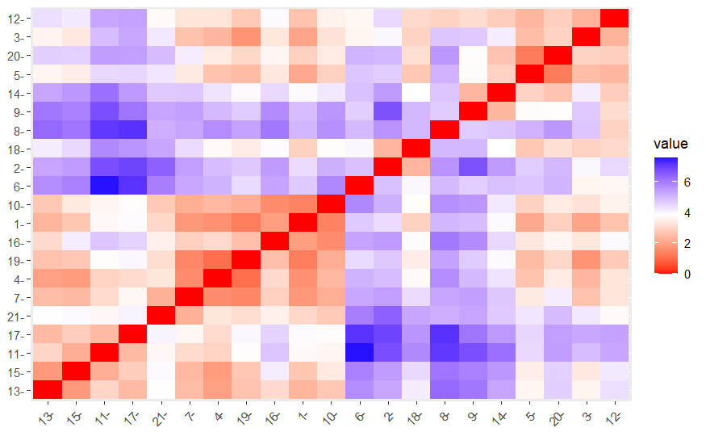

```r
# Scaling the data frame (z-score)
Pharmaceuticals <- scale(Pharmaceuticals)
distance <- get_dist(Pharmaceuticals)
fviz_dist(distance)
```

The above graph shows the distance between the financial data of the 21 firms.

Let us now run the k-means algorithm to cluster the firms. We will first determine the best k by using various methods.

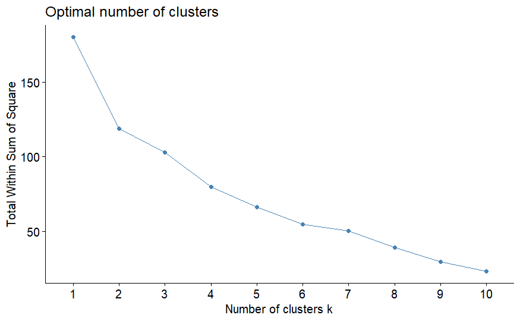

```r
#This is the elbow chart method
Pharmaceuticals <- scale(Pharmaceuticals)
fviz_nbclust(Pharmaceuticals, kmeans, method ="wss")
```

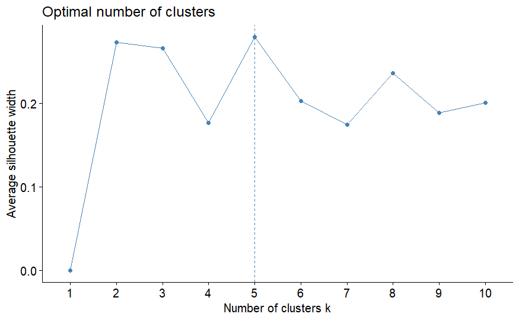

```r
#This is the Silhouette Method
fviz_nbclust(Pharmaceuticals,kmeans, method = "silhouette")
```

B. Interpret the clusters with respect to the numerical variables used in forming the clusters.

Here, we use cluster centroids, squared distances, and cluster size using k=5

```r
#centroids
k5$centers
```

```
   Market_Cap       Beta    PE_Ratio        ROE        ROA Asset_Turnover    Leverage Rev_Growth Net_Profit_Margin
1 -0.43925134 -0.4701800  2.70002464 -0.8349525 -0.9234951      0.2306328 -0.14170336 -0.1168459      -1.416514761
2 -0.76022489  0.2796041 -0.47742380 -0.7438022 -0.8107428     -1.2684804  0.06308085  1.5180158      -0.006893899
3 -0.03142211 -0.4360989 -0.31724852  0.1950459  0.4083915      0.1729746 -0.27449312 -0.7041516       0.556954446
4 -0.87051511  1.3409869 -0.05284434 -0.6184015 -1.1928478     -0.4612656  1.36644699 -0.6912914      -1.320000179
5  1.69558112 -0.1780563 -0.19845823  1.2349879  1.3503431      1.1531640 -0.46807818  0.4671788       0.591242521
```

```r
#squared distances
k5$withinss
```

```
[1]  2.803505 12.791257 21.879320 15.595925  9.284424
```

```r
#cluster size
k5$size
```

```
[1] 2 4 8 3 4
```

In the table above, our findings are that: - Cluster 1 has the highest PE_Ratio - Cluster 2 has lowest PE_Ratio but highest Rev_Growth - Cluster 3 has lowest Rev_Growth - Cluster 4 has lowest Market_Cap but highest Beta - Cluster 5 has highest Market_Cap, ROE, ROA, Asset Turnover, and Net_Profit_Margin

Finally using the squared distances and cluster size we can compare which cluster is more homogeneous than the other.For example, Cluster 3 (which has eight records) has the biggest within sum-distance while Cluster 4 (with three records) has a smaller within sum-distance. This means that Cluster 4 most likely has the same types/kind of records than Cluster 3.

```r
k5$cluster[10] # Identify the cluster of the 10th observation
```

```
[1] 3
```

This observation corresponds with the number of records and in which cluster as stated in the previous table.

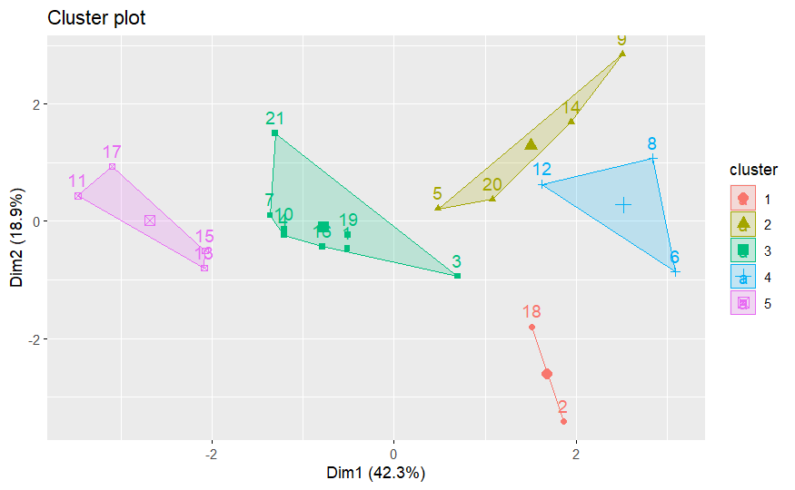

```r
fviz_cluster(k5, data = Pharmaceuticals) # Visualize the output
```

C. Is there a pattern in the clusters with respect to the numerical variables (10 to 12)? (those not used in forming the clusters)

Yes, there is a pattern. Here are some examples: - Cluster 1 which has the highest PE_Ratio are mostly ‘MODERATE BUY’, located in NORTH AMERICA (US/CANADA), and are listed under NYSE. - Cluster 2 which has lowest PE_Ratio and highest Rev_Growth are mostly ‘MODERATE BUY’, located in EUROPE (etc. France and Ireland), and are listed under NYSE. - Cluster 3 which has lowest Rev_Growth are mostly ‘HOLD’, located in the US, and are all listed under NYSE. - Cluster 5 which has highest Market_Cap, ROE, ROA, Asset Turnover, and Net_Profit_Margin are both ‘MODERATE BUY’ and ‘HOLD’, located in the US, and are under NYSE.

D. Provide an appropriate name for each cluster using any or all of the variables in the dataset.

```r
#create scatter plot
plot(c(0), xaxt = "n", xlab = 'Variables', ylab = " ", type = "l",
     ylim = c(min(k5$centers), max(k5$centers)),
     xlim = c(0,9))

#label x-axes
axis(1, at = c(1:9), labels = names(Pharmaceuticals))
```

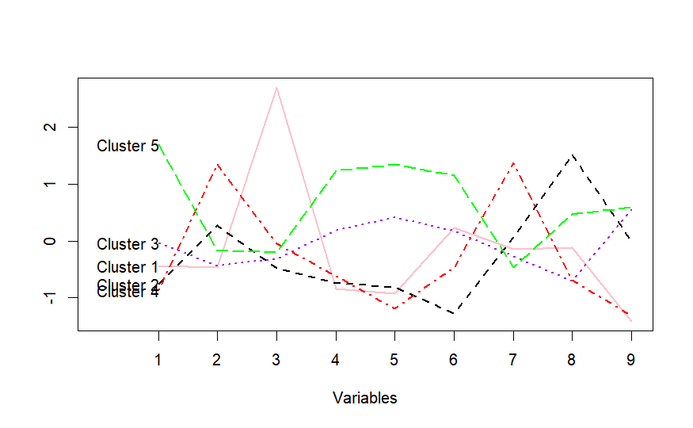

```r
#plotting centroids
for (i in c(1:5))
  lines (k5$centers[i,], lty = i, lwd =2,
         col =ifelse(i %in% c(1), "pink",
                     (ifelse (i %in% c(2), "black",
                              (ifelse (i %in% c(3), "purple",
                                       (ifelse (i %in% c(4),"red",
                                                (ifelse (i %in% c(5), "green"))))))))))
#naming clusters
text(x = .5, y =k5$centers[, 1], labels = paste ("Cluster", c(1:5)))
```

- Cluster 1 can be named : Big PE_Ratio
- Cluster 2 can be named : Low PE_Ratio w/ High Rev_Growth
- Cluster 3 can be named: Small Rev_Growth
- Cluster 4 can be named : Small Market Cap w/ High Beta
- Cluster 5 can be named: Highest and best cluster